# 深度卷积网络与计算机图像

## 目录

> - 平移不变与空间不变特性
> - 卷积核及其作用
> - Batch Normalization
> - Pooling and Dropout
> - AlexNet、ResNet、DenseNet
> - Reception方法
> - CNN的GPU加速方法
> - 卷积网络的可视化分析
> - Convolutional Neural Network

## 卷积

- parameters sharing

### 一维卷积

[figure not shown]

### 二维卷积

[figure not shown]

### 三维卷积-图像

[figure not shown]

### Local invariant

[figure not shown]

### 卷积核有什么作用呢？

#### 一阶求导

[figure not shown]

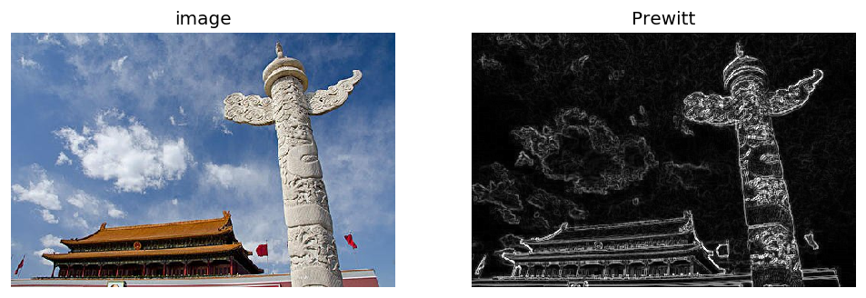

```python
# -*- coding: utf-8 -*-
import cv2
import numpy as np
import matplotlib.pyplot as plt

# 读取图像
img = cv2.imread('故宫.jpg')

# imread 读的彩色图按照BGR像素存储、转换为RGB
img_RGB = cv2.cvtColor(img, cv2.COLOR_BGR2RGB)

# 灰度化处理图像
grayImage = cv2.cvtColor(img, cv2.COLOR_BGR2GRAY)

# Prewitt算子
kernelx = np.array([[1, 1, 1], [0, 0, 0], [-1, -1, -1]], dtype=int)
kernely = np.array([[-1, 0, 1], [-1, 0, 1], [-1, 0, 1]], dtype=int)
x = cv2.filter2D(grayImage, cv2.CV_16S, kernelx)
y = cv2.filter2D(grayImage, cv2.CV_16S, kernely)

# 转uint8
absX = cv2.convertScaleAbs(x)
absY = cv2.convertScaleAbs(y)
Prewitt = cv2.addWeighted(absX, 0.5, absY, 0.5, 0)

# 显示结果
plt.figure(figsize=(10,10),dpi=120)
plt.subplot(121),plt.imshow(img_RGB),plt.title('image'), plt.axis('off') #坐标轴关闭
plt.subplot(122),plt.imshow(Prewitt, cmap=plt.cm.gray ),plt.title('Prewitt'), plt.axis('off')
plt.show()
```

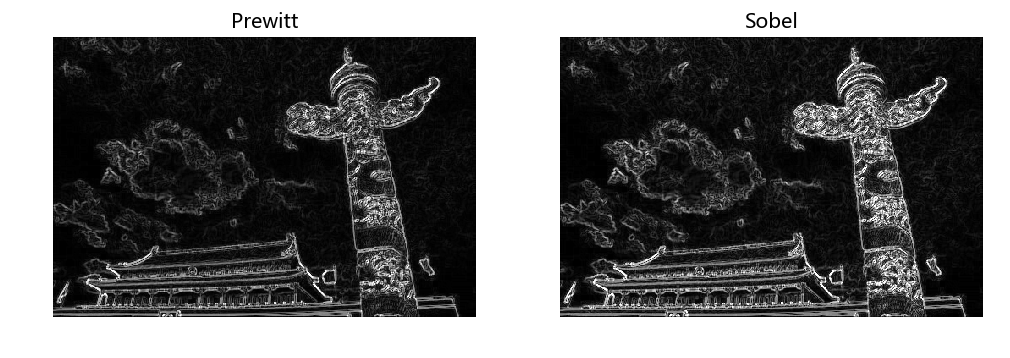

```python
# Sobel算子
x = cv2.Sobel(grayImage, cv2.CV_16S, 1, 0)  # 对x求一阶导
y = cv2.Sobel(grayImage, cv2.CV_16S, 0, 1)  # 对y求一阶导
absX = cv2.convertScaleAbs(x)
absY = cv2.convertScaleAbs(y)
Sobel = cv2.addWeighted(absX, 0.5, absY, 0.5, 0)

# 显示结果
plt.figure(figsize=(10,10),dpi=120)
plt.subplot(121),plt.imshow(Prewitt, cmap=plt.cm.gray ),plt.title('Prewitt'), plt.axis('off')
plt.subplot(122),plt.imshow(Sobel, cmap=plt.cm.gray ),plt.title('Sobel'), plt.axis('off')
plt.show()
```

#### 二阶求导

[figure not shown]

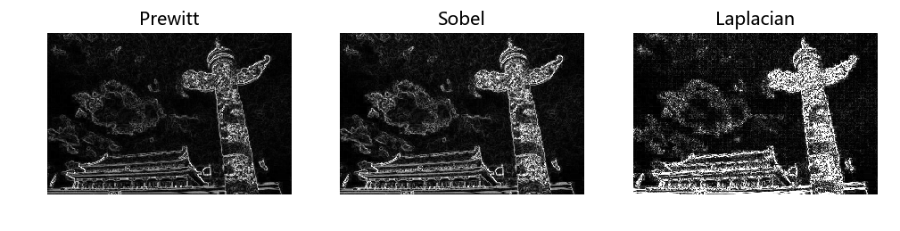

```python
# 拉普拉斯算法
dst = cv2.Laplacian(grayImage, cv2.CV_16S, ksize=3)
Laplacian = cv2.convertScaleAbs(dst)

# 显示结果
plt.figure(figsize=(10,10),dpi=120)
#plt.subplot(141),plt.imshow(img_RGB),plt.title('image'), plt.axis('off') #坐标轴关闭
plt.subplot(131),plt.imshow(Prewitt, cmap=plt.cm.gray ),plt.title('Prewitt'), plt.axis('off')
plt.subplot(132),plt.imshow(Sobel, cmap=plt.cm.gray ),plt.title('Sobel'), plt.axis('off')
plt.subplot(133),plt.imshow(Laplacian, cmap=plt.cm.gray ),plt.title('Laplacian'), plt.axis('off')
plt.show()
```

#### feature maps

[figure not shown]

### padding

#### Same Padding

[figure not shown]

#### Valid Padding

[figure not shown]

### strides

[figure not shown]

### What is receptive field ?

[figure not shown]

### 卷积计算公式

> 输入图片的宽、高、通道数为$W_{in} \times H_{in} \times D_{in}$

> 卷积核的大小为$F\times F$、步长为$S$、Padding为$P$、卷积核的个数为$K$。

> 根据卷积的通用公式1-1、1-2、1-3，可得输出特征图的宽、高、通道数（$W_{out} \times H_{out} \times D_{out}$）。

$$ W_{out} = \frac{W_{in}-F+2\times P}{S}+1\tag{1-1} $$$$ H_{out} = \frac{H_{in}-F+2\times P}{S}+1 \tag{1-2} $$$$ D_{out} = K \tag{1-3} $$

## What pooling layers do ?

[figure not shown]

### max pooling and average pooling

[figure not shown]

### 池化层计算公式

> 池化（Pool）层，它可以对图片进行压缩（降采样），简化网络计算复杂度。

> 池化层中的核大小为$F\times F$，步长为$S$。

> 可利用池化通用公式1-4、1-5、1-6，知道经过池化层的特征图大小。

$$ W_{out} = \frac{W_{in}-F}{S}+1 \tag{1-4} $$$$ H_{out} = \frac{H_{in}-F}{S}+1 \tag{1-5} \\ $$$$ D_{out} = D_{in} \tag{1-6} $$

## Dropout Layer

[figure not shown]

## train:

# test:

## Batch Normalization

[figure not shown]

## BackBone

[figure not shown]

## AlexNet

[figure not shown]

```python
import torch
from torch import nn, optim
import torchvision

device = torch.device('cuda' if torch.cuda.is_available() else 'cpu')

class AlexNet(nn.Module):

    def __init__(self):
        super(AlexNet, self).__init__()
        self.conv = nn.Sequential(
            nn.Conv2d(1, 96, 11, 4), # in_channels, out_channels, kernel_size, stride, padding
            nn.ReLU(),
            nn.MaxPool2d(3, 2), # kernel_size, stride
        # 减小卷积窗⼝口，使用填充为2来使得输入与输出的高和宽一致，且增⼤输出通道数
            nn.Conv2d(96, 256, 5, 1, 2),
            nn.ReLU(),
            nn.MaxPool2d(3, 2),
        # 连续3个卷积层，且使用更小的卷积窗口。除了最后的卷积层外，进一步 增⼤了输出通道数。
        # 前两个卷积层后不使用池化层来减小输入的⾼和宽
            nn.Conv2d(256, 384, 3, 1, 1),
            nn.ReLU(),
            nn.Conv2d(384, 384, 3, 1, 1),
            nn.ReLU(),
            nn.Conv2d(384, 256, 3, 1, 1),
            nn.ReLU(),
            nn.MaxPool2d(3, 2)
)
        # 这里全连接层的输出个数⽐ALexNet中的⼤数倍。使⽤dropout来缓解过拟合。
        self.fc = nn.Sequential(
            nn.Linear(256*5*5, 4096),
            nn.ReLU(),
            nn.Dropout(0.5),
            nn.Linear(4096, 4096),
            nn.ReLU(),
            nn.Dropout(0.5),
        # 输出层，论⽂1000
            nn.Linear(4096, 1000),
        )
def forward(self, img):
    feature = self.conv(img)
    output = self.fc(feature.view(img.shape[0], -1))
    return output
```

```python
net = AlexNet()
print(net)
```

```
AlexNet(
  (conv): Sequential(
    (0): Conv2d(1, 96, kernel_size=(11, 11), stride=(4, 4))
    (1): ReLU()
    (2): MaxPool2d(kernel_size=3, stride=2, padding=0, dilation=1, ceil_mode=False)
    (3): Conv2d(96, 256, kernel_size=(5, 5), stride=(1, 1), padding=(2, 2))
    (4): ReLU()
    (5): MaxPool2d(kernel_size=3, stride=2, padding=0, dilation=1, ceil_mode=False)
    (6): Conv2d(256, 384, kernel_size=(3, 3), stride=(1, 1), padding=(1, 1))
    (7): ReLU()
    (8): Conv2d(384, 384, kernel_size=(3, 3), stride=(1, 1), padding=(1, 1))
    (9): ReLU()
    (10): Conv2d(384, 256, kernel_size=(3, 3), stride=(1, 1), padding=(1, 1))
    (11): ReLU()
    (12): MaxPool2d(kernel_size=3, stride=2, padding=0, dilation=1, ceil_mode=False)
  )
  (fc): Sequential(
    (0): Linear(in_features=6400, out_features=4096, bias=True)
    (1): ReLU()
    (2): Dropout(p=0.5, inplace=False)
    (3): Linear(in_features=4096, out_features=4096, bias=True)
    (4): ReLU()
    (5): Dropout(p=0.5, inplace=False)
    (6): Linear(in_features=4096, out_features=1000, bias=True)
  )
)
```

## VGG

[figure not shown]

### CNN example (An image classifier)

[figure not shown]

```python
import torch
import torchvision
from torch.utils.data import DataLoader
import torch.nn as nn
import torch.optim as optim
import torchvision.transforms as transforms

# 预处理的设置
# 图片转化为 backbone网络 规定的图片大小
# 归一化是减去均值，除以方差
# 把 numpy array 转化为 tensor 的格式
my_tf = transforms.Compose([
    transforms.Resize((224,224)),
    transforms.ToTensor(),
    transforms.Normalize([0.4914, 0.4822, 0.4465], [0.247, 0.243, 0.261])])

# 读取数据集 cifar-10 的图，有10个类，5万张图片。进行预处理。
train_dataset = torchvision.datasets.CIFAR10(root='./',train=True,transform=my_tf,download=True)
test_dataset = torchvision.datasets.CIFAR10(root='./',train=False,transform=my_tf,download=True)

# 调用预训练模型vgg16
my_vgg = torchvision.models.vgg16(pretrained=True)
# 固定网络框架全连接层之前的参数
for param in my_vgg.parameters():
    param.requires_grad=False
# 将vgg最后一层输出的类别数，改为cifar-10的类别数（10）
in_f = my_vgg.classifier[6].in_features
my_vgg.classifier[6] = nn.Linear(in_f,10)

# 超参数设置
learn_rate = 0.001
num_epoches = 10
# 多分类损失函数，使用默认值
criterion = nn.CrossEntropyLoss()
# 梯度下降，求解模型最后一层参数
optimizer = optim.SGD(my_vgg.classifier[6].parameters(),lr=learn_rate,momentum=0.9)
# 判断使用CPU还是GPU
device = torch.device('cuda') if torch.cuda.is_available() else torch.device('cpu')
# 图片分批次送入内存（32张图片,batch_size），进行计算。
train_dataloader = DataLoader(dataset=train_dataset,batch_size=32,shuffle=True)
test_dataloader = DataLoader(dataset=test_dataset)

# 训练阶段
my_vgg.to(device)
my_vgg.train()
for epoch in range(num_epoches):
    print(f"epoch: {epoch+1}")
    for idx,(img,label)in enumerate(train_dataloader):
        images = img.to(device)
        labels = label.to(device)
        output = my_vgg(images)
        loss = criterion(output,labels)
        loss.backward() # 损失反向传播
        optimizer.step() # 更新梯度
        optimizer.zero_grad() # 梯度清零
        if idx%100==0:
            print(f"current loss = {loss.item()}")

# 测试阶段
my_vgg.to(device)
my_vgg.eval() # 把训练好的模型的参数冻结
total,correct = 0 , 0
for img,label in test_dataloader:
    images = img.to(device)
    labels = label.to(device)
    output = my_vgg(images)
    _,idx = torch.max(output.data,1) # 输出最大值的位置
    total += labels.size(0) # 全部图片
    correct +=(idx==labels).sum() # 正确的图片

print(f"accuracy:{100.*correct/total}")
```

[output not shown]

## GoogLeNet

### Inception Module

[figure not shown]

## ResNet

### Bottleneck

[figure not shown]

### ResNet

[figure not shown]

### FLOPs

> FLOPs(floating-point operations)指的是浮点运算次数，FLOPs可以衡量框架的复杂度。框架的复杂度与权重和bias有关。  
> 输入图像的高、宽、通道数用 $H_{in}$、 $W_{in}$、$D_{in}$；  
> 输出的特征图的高、宽、通道数用$H_{out}$、 $W_{out}$、$ D_{out}$表示。  
> 卷积核的宽和高用$F_w$、$F_h$表示。  
> $N_p$ 表示特征图一个点的计算量。

$$ N_p = (F_w\times F_h\times D_{in}) \times D_{out} + D_{out} \tag{1-7} $$$$ FLOPs: N_P \times H_{out} \times W_{out} \tag{1-8} $$

> 对于全连接层，输入的特征图会拉伸为$1*N_{in}$的向量，输出的向量维度为$1*N_{out}$。

$$ FLOPs:N_{in} \times N_{out} + N_{out} \tag{1-9} $$

[figure not shown]

图1-10

> 也可以使用工具包[Flops counter](https://github.com/sovrasov/flops-counter.pytorch)在pytorch中计算网络的复杂度，根据网址的介绍安装工具包。

> 例子

```
import torch
import torchvision.models as models # 导入网络框架
import ptflops # 导入计算FLOPs的包
ptflops.get_model_complexity_info(models.vgg16(), (3,224,224))
# ('15.5 GMac', '138.36 M')
```

## DenseNet

[figure not shown]

## GPU加速

[GPU计算加速](https://zhuanlan.zhihu.com/p/76297133)  
[Pytorch 如何高效使用GPU](http://www.feiguyunai.com/index.php/2019/04/30/python-ml-25-pytorch-gpu/)

```python
import torch
print(torch.__version__)
print(torch.cuda.is_available())
print(torch.version.cuda)
```

```
1.3.1
False
None
```

## 卷积网络的可视化分析

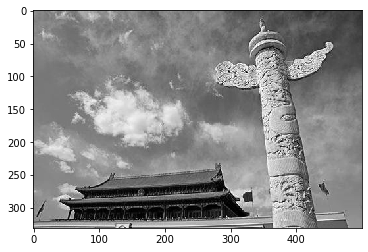

```python
import cv2
import numpy as np
import matplotlib.pyplot as plt

# 读取图像
img = cv2.imread('故宫.jpg')

# imread 读的彩色图按照BGR像素存储、转换为RGB
img_RGB = cv2.cvtColor(img, cv2.COLOR_BGR2RGB)

# 灰度化处理图像
grayImage = cv2.cvtColor(img, cv2.COLOR_BGR2GRAY)

# Normalise
grayImage = grayImage.astype("float32")/255

plt.imshow(grayImage, cmap='gray')
plt.show()
```

[output not shown]

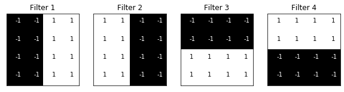

```python
filter_vals = np.array([
  [-1, -1, 1, 1],
  [-1, -1, 1, 1],
  [-1, -1, 1, 1],
  [-1, -1, 1, 1]
])

print('Filter shape: ', filter_vals.shape)

# Defining the Filters
filter_1 = filter_vals
filter_2 = -filter_1
filter_3 = filter_1.T
filter_4 = -filter_3
filters = np.array([filter_1, filter_2, filter_3, filter_4])

# Check the Filters
fig = plt.figure(figsize=(10, 5))
for i in range(4):
    ax = fig.add_subplot(1, 4, i+1, xticks=[], yticks=[])
    ax.imshow(filters[i], cmap='gray')
    ax.set_title('Filter %s' % str(i+1))
    width, height = filters[i].shape
    for x in range(width):
        for y in range(height):
            ax.annotate(str(filters[i][x][y]), xy=(y,x),
                        color='white' if filters[i][x][y]<0 else 'black')
```

```python
import torch
import torch.nn as nn
import torch.nn.functional as F

class Net(nn.Module):

    def __init__(self, weight):
        super(Net, self).__init__()
        # initializes the weights of the convolutional layer to be the weights of the 4 defined filters
        k_height, k_width = weight.shape[2:]
        # assumes there are 4 grayscale filters
        self.conv = nn.Conv2d(1, 4, kernel_size=(k_height, k_width), bias=False)
        # initializes the weights of the convolutional layer
        self.conv.weight = torch.nn.Parameter(weight)
        # define a pooling layer
        self.pool = nn.MaxPool2d(2, 2)

    def forward(self, x):
        # calculates the output of a convolutional layer
        # pre- and post-activation
        conv_x = self.conv(x)
        activated_x = F.relu(conv_x)

        # applies pooling layer
        pooled_x = self.pool(activated_x)

        # returns all layers
        return conv_x, activated_x, pooled_x

    # instantiate the model and set the weights
weight = torch.from_numpy(filters).unsqueeze(1).type(torch.FloatTensor)
model = Net(weight)

# print out the layer in the network
print(model)
```

```
Net(
  (conv): Conv2d(1, 4, kernel_size=(4, 4), stride=(1, 1), bias=False)
  (pool): MaxPool2d(kernel_size=2, stride=2, padding=0, dilation=1, ceil_mode=False)
)
```

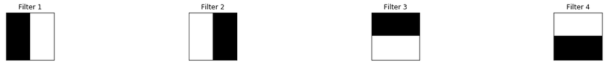

[figure not shown]

[figure not shown]

[figure not shown]

```python
def viz_layer(layer, n_filters= 4):
    fig = plt.figure(figsize=(20, 20))

    for i in range(n_filters):
        ax = fig.add_subplot(1, n_filters, i+1)
        ax.imshow(np.squeeze(layer[0,i].data.numpy()), cmap='gray')
        ax.set_title('Output %s' % str(i+1))

fig = plt.figure(figsize=(12, 6))
fig.subplots_adjust(left=0, right=1.5, bottom=0.8, top=1, hspace=0.05, wspace=0.05)
for i in range(4):
    ax = fig.add_subplot(1, 4, i+1, xticks=[], yticks=[])
    ax.imshow(filters[i], cmap='gray')
    ax.set_title('Filter %s' % str(i+1))

# convert the image into an input Tensor
gray_img_tensor = torch.from_numpy(grayImage).unsqueeze(0).unsqueeze(1)

# get the convolutional layer (pre and post activation)
conv_layer, activated_layer, pool_layer = model(gray_img_tensor)

# visualize the output of a conv layer
viz_layer(conv_layer)

# visualize the output of activate layer
viz_layer(activated_layer)

# visualize the output of a pool layer
viz_layer(pool_layer)
```